# iLykei Lecture Series Machine Learning Decision Trees Workshop 3

## 1.3 Classification performance evaluation for several classes

Let $N$ be the number of objects to classify, $M$ - number of classes, let also $y_{ij}$ be 1 if object $i$ belongs to class $j$, and 0 otherwise.
Finally, let $p_{ij}$ be predicted probability that object $i$ belongs to class $j$.
Vector $<p_{i1},p_{i2},.,p_{i,M}>$ is the output of the classification algorithm for object $i$.
A popular classification performance estimate is **logloss**.
The formula for logloss is
$$logloss=-\frac{1}{N}\sum_{i=1}^{N}\sum_{j=1}^{M}y_{ij}\ln (p_{ij}).$$
For example, let the number of classes be $M=2$ and there is only one object that needs to be classified. Then the logloss formula is
$$logloss=-y_{11}\ln (p_{11})-y_{12}\ln (p_{12}).$$
If for this object the correct class is 1 then $y_{11}=1$, $y_{12}=0$ and $logloss= - \ln (p_{11})$.
Suppose the ideal case when the classification algorithm returned vector $<1,0>$. Then $logloss=0$.
If the algorithm classifies correctly, but assigns more uncertainty to the first class: $<0.7,0.3>$ then the penalty function is $logloss=-\ln (0.7)$ = 0.3566749.
If predicted probability for the first class is small the penalty function can potentially go to infinity. That is why in practice input values $p_{ij}$ are replaced by $\max (C,p_{ij})$, where $C$ is a small positive number.
For example, if $C=10^{-16}$ an incorrect forecast is a subject to a penalty of 36.8413615.

Write function `MultiLogLoss <- function(act, pred)` for calculation of logloss using the formula above.  
Argument `act` is a matrix $y_{ij},~i=1,\ldots,N;~j=1,\ldots,M,$ of actual classes. Each row $i$ should contain $M$ elements, all of them are zeros, except for position $t$ corresponding to the true class of observation $i$: $y_{it}=1$.  
Argument `pred` is the matrix of prediction probabilities $p_{ij}$ of the same size as $y_{ij}$. Each row of this matrix is the vector of probabilities of observation $i$ belonging to class $j$.

```r
MultiLogLoss <- function(act, pred)
{
  eps = 1e-15;
  if (!is.matrix(pred)) pred<-t(as.matrix(pred))
  if (!is.matrix(act)) act<-t(as.matrix(act))
  nr <- nrow(pred)
  pred = matrix(sapply( pred, function(x) max(eps,x)), nrow = nr)
  pred = matrix(sapply( pred, function(x) min(1-eps,x)), nrow = nr)
  #normalize rows
  ll = sum(act*log(sweep(pred, 1, rowSums(pred), FUN="/")))
  ll = -ll/nrow(act)
  return(ll);
}
```

Check the logloss function for the following examples.

```r
(ac<-rbind(c(0,1,0,0,0),c(0,0,0,0,1)))
```

```
##      [,1] [,2] [,3] [,4] [,5]
## [1,]    0    1    0    0    0
## [2,]    0    0    0    0    1
```

```r
(pr<-rbind(c(0,1,0,0,0),c(0,0,0,0,1)))
```

```
##      [,1] [,2] [,3] [,4] [,5]
## [1,]    0    1    0    0    0
## [2,]    0    0    0    0    1
```

```r
MultiLogLoss(ac, pr)
```

```
## [1] 4.107825e-15
```

```r
(pr<-rbind(c(0.02,.92,0.02,0.02,0.02),c(0.02,0.02,0.02,0.02,.98)))
```

```
##      [,1] [,2] [,3] [,4] [,5]
## [1,] 0.02 0.92 0.02 0.02 0.02
## [2,] 0.02 0.02 0.02 0.02 0.98
```

```r
MultiLogLoss(ac, pr)
```

```
## [1] 0.08092661
```

Check calculation of the function manually:

```r
pr1<-t(apply(pr,1,function(z) z/sum(z))) #Do not forget to normalize rows of pr!
-(sum(ac[1,]*log(pr1[1,]))+sum(ac[2,]*log(pr1[2,])))/2
```

```
## [1] 0.08092661
```

```r
MultiLogLoss(ac[1,], pr[1,])
```

```
## [1] 0.08338161
```

```r
MultiLogLoss(ac[2,], pr[2,])
```

```
## [1] 0.07847162
```

```r
(MultiLogLoss(ac[1,], pr[1,])+MultiLogLoss(ac[2,], pr[2,]))/2
```

```
## [1] 0.08092661
```

# 2 Recursive Partitioning Using the RPART Package

## 2.1 Example: Manual implementation of Gini impurity measure

To understand Gini impurity measure create a simple vector containing 2 classes:

Create predictor and data frame.

```r
library(rpart)
library(rpart.plot)
```

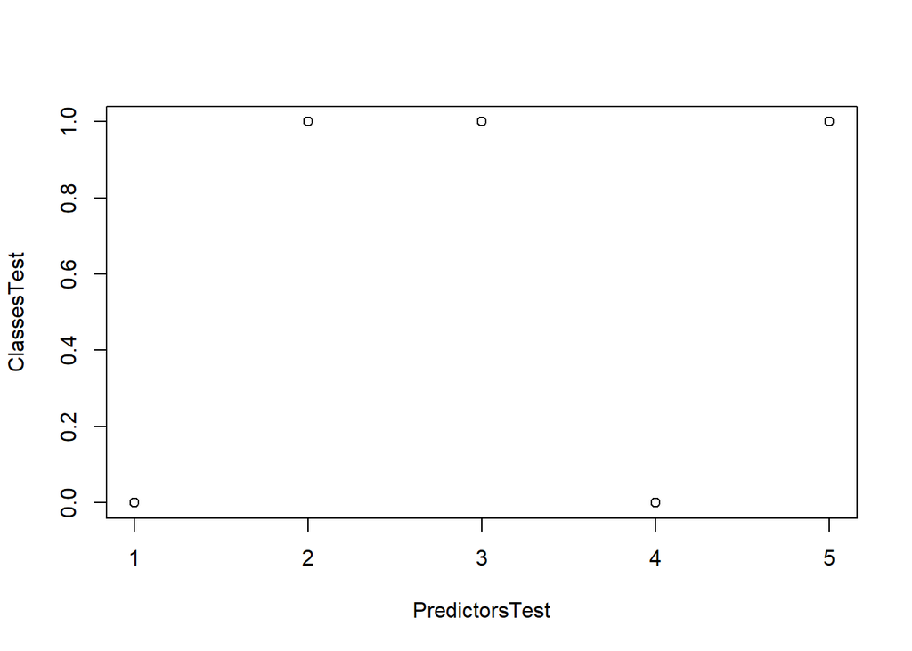

```r
ClassesTest<-c(0,1,1,0,1)
PredictorsTest<-c(1,2,3,4,5)
TestData<-as.data.frame(cbind(PredictorsTest,ClassesTest))
plot(TestData)
```

Run classification tree algorithm.

```r
testTree<-rpart(ClassesTest~PredictorsTest, data=TestData,
              control = rpart.control(cp = 0.00,minbucket=1,minsplit=2),method="class")
printcp(testTree)
```

```
##
## Classification tree:
## rpart(formula = ClassesTest ~ PredictorsTest, data = TestData,
##     method = "class", control = rpart.control(cp = 0, minbucket = 1,
##         minsplit = 2))
##
## Variables actually used in tree construction:
## [1] PredictorsTest
##
## Root node error: 2/5 = 0.4
##
## n= 5
##
##     CP nsplit rel error xerror    xstd
## 1 0.50      0       1.0    2.5 0.00000
## 2 0.25      1       0.5    1.5 0.54772
## 3 0.00      3       0.0    2.0 0.44721
```

The table shows the splits, the cost function for complexity of the tree `cp` and the two errors: before and after cross validation.

Visualize the tree.

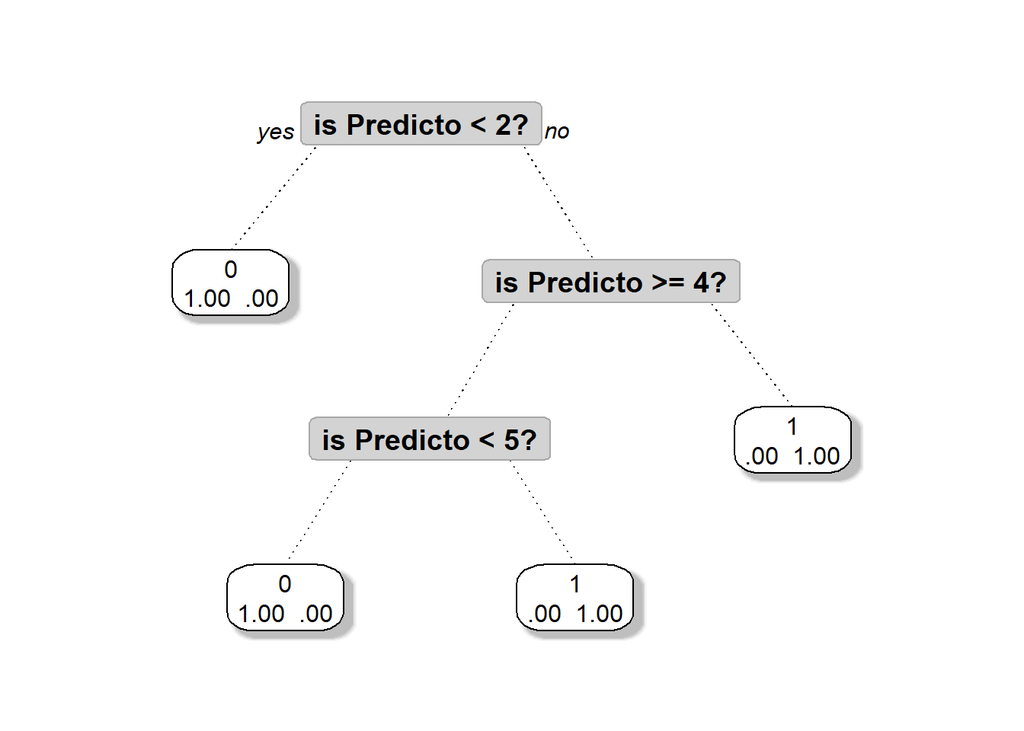

```r
prp(testTree,extra=4, # display prob of classes in the node
    branch=.5, # change angle of branch lines
    shadow.col="gray", # shadows under the leaves
    branch.lty=3, # draw branches using dotted lines
    split.cex=1.2, # make the split text larger than the node text
    split.prefix="is ", # put "is " before split text
    split.suffix="?", # put "?" after split text
    split.box.col="lightgray", # lightgray split boxes (default is white)
    split.border.col="darkgray", # darkgray border on split boxes
    split.round=.5)
```

Parameter `extra=4` shows class predicted by the leaf and probabilities of classes (total is 1).

The CP-table shows that the tree can be pruned: `xerror` is up in the last row.  
Find the best CP level.

```r
(best.CP = testTree$cptable[which.min(testTree$cptable[,"xerror"]),"CP"])
```

```
## [1] 0.25
```

Prune the tree to the best CP level.

```r
prunedTree <- prune(testTree, cp = best.CP)
printcp(prunedTree)
```

```
##
## Classification tree:
## rpart(formula = ClassesTest ~ PredictorsTest, data = TestData,
##     method = "class", control = rpart.control(cp = 0, minbucket = 1,
##         minsplit = 2))
##
## Variables actually used in tree construction:
## [1] PredictorsTest
##
## Root node error: 2/5 = 0.4
##
## n= 5
##
##     CP nsplit rel error xerror    xstd
## 1 0.50      0       1.0    2.5 0.00000
## 2 0.25      1       0.5    1.5 0.54772
```

Show the tree

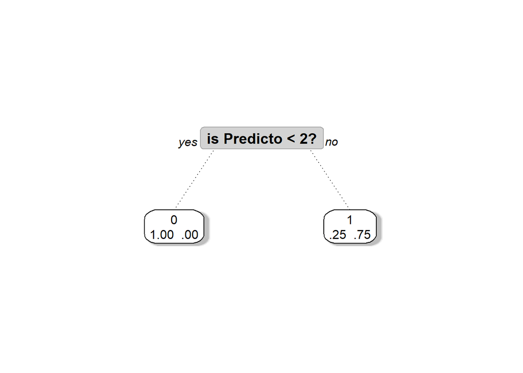

```r
prp(prunedTree,extra=4, # display prob of classes in the node
    branch=.5, # change angle of branch lines
    shadow.col="gray", # shadows under the leaves
    branch.lty=3, # draw branches using dotted lines
    split.cex=1.2, # make the split text larger than the node text
    split.prefix="is ", # put "is " before split text
    split.suffix="?", # put "?" after split text
    split.box.col="lightgray", # lightgray split boxes (default is white)
    split.border.col="darkgray", # darkgray border on split boxes
    split.round=.5)
```

Check how Gini impurity measure makes decisions about branching the tree at each step.

Simplify the task by assigning lower values of the predictor to the first class and higher values to the second class.  
**How does that simplify the tree?**

```r
PredictorsTest<-c(2,5,3,1,4)
TestData<-as.data.frame(cbind(PredictorsTest,ClassesTest))
testTree<-rpart(ClassesTest~PredictorsTest, data=TestData,
              control = rpart.control(cp = 0.00,minbucket=1,minsplit=2),method="class")
printcp(testTree)
```

```
##
## Classification tree:
## rpart(formula = ClassesTest ~ PredictorsTest, data = TestData,
##     method = "class", control = rpart.control(cp = 0, minbucket = 1,
##         minsplit = 2))
##
## Variables actually used in tree construction:
## [1] PredictorsTest
##
## Root node error: 2/5 = 0.4
##
## n= 5
##
##   CP nsplit rel error xerror    xstd
## 1  1      0         1    2.5 0.00000
## 2  0      1         0    0.5 0.44721
```

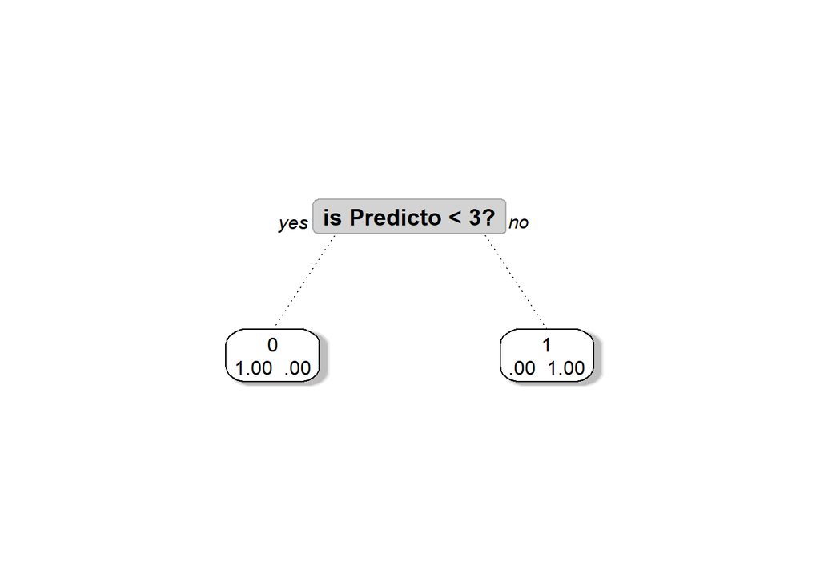

```r
prp(testTree,extra=4, # display prob of classes in the node
    branch=.5, # change angle of branch lines
    shadow.col="gray", # shadows under the leaves
    branch.lty=3, # draw branches using dotted lines
    split.cex=1.2, # make the split text larger than the node text
    split.prefix="is ", # put "is " before split text
    split.suffix="?", # put "?" after split text
    split.box.col="lightgray", # lightgray split boxes (default is white)
    split.border.col="darkgray", # darkgray border on split boxes
    split.round=.5)
```

## 2.2 Example: Mixture model

Create a mixture model of two Gaussian distributions.

```r
library(nor1mix)
```

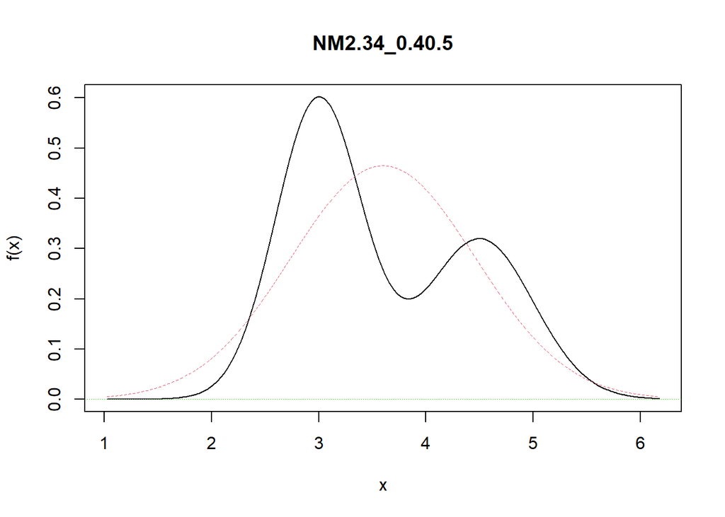

```r
set.seed(3890)
norMixObj<-norMix(mu=c(3,4.5),sigma=c(.4,.5),w=c(.6,.4))
plot(norMixObj)
```

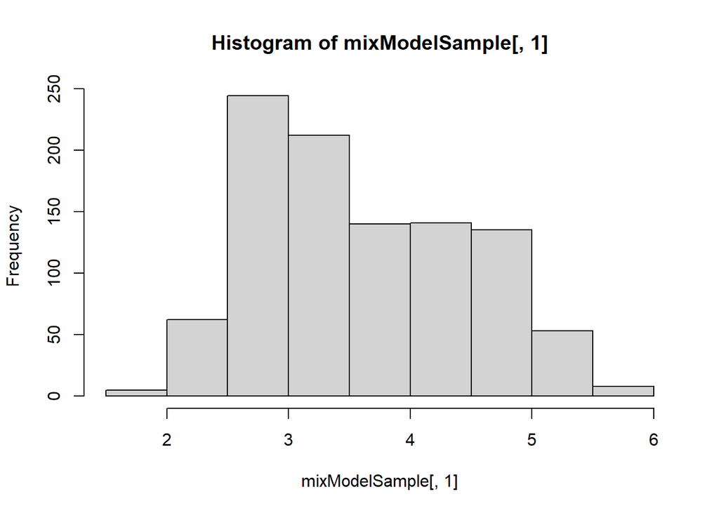

```r
mixModelSample<-rbind(cbind(rnorm(600,mean=3,sd=.4),rep(0,600)),cbind(rnorm(400,mean=4.5,sd=.5),rep(1,400)))
hist(mixModelSample[,1])
```

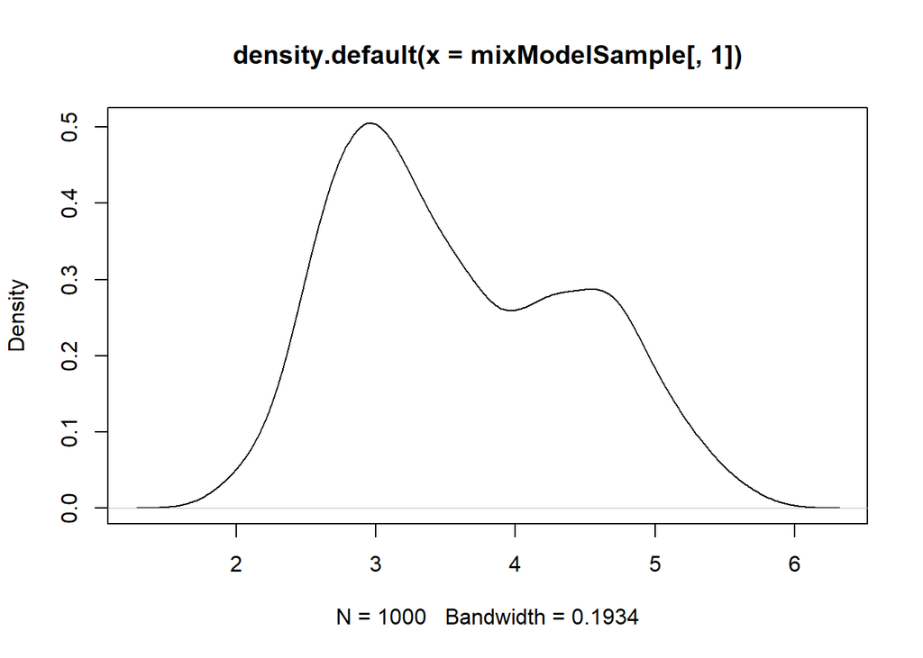

```r
plot(density(mixModelSample[,1]))
```

Reshuffle the rows.

```r
mixModelSample<-mixModelSample[sample(nrow(mixModelSample)),]
```

Cluster the sample using function `Mclust()` from library `mclust`.

```r
library(mclust)
citation("mclust")
```

```
##
##
##   Scrucca L., Fop M., Murphy T. B. and Raftery A. E. (2016) mclust 5:
##   clustering, classification and density estimation using Gaussian
##   finite mixture models The R Journal 8/1, pp. 289-317
##
## A BibTeX entry for LaTeX users is
##
##   @Article{,
##     title = {{mclust} 5: clustering, classification and density estimation using {G}aussian finite mixture models},
##     author = {Luca Scrucca and Michael Fop and T. Brendan Murphy and Adrian E. Raftery},
##     journal = {The {R} Journal},
##     year = {2016},
##     volume = {8},
##     number = {1},
##     pages = {289--317},
##     url = {https://doi.org/10.32614/RJ-2016-021},
##   }
```

```r
EstimatedModel<-Mclust(mixModelSample[,1],modelNames="V")
names(EstimatedModel)
```

```
##  [1] "call"           "data"           "modelName"      "n"
##  [5] "d"              "G"              "BIC"            "loglik"
##  [9] "df"             "bic"            "icl"            "hypvol"
## [13] "parameters"     "z"              "classification" "uncertainty"
```

```r
EstimatedModel$parameters
```

```
## $pro
## [1] 0.5781169 0.4218831
##
## $mean
##        1        2
## 2.985141 4.431413
##
## $variance
## $variance$modelName
## [1] "V"
##
## $variance$d
## [1] 1
##
## $variance$G
## [1] 2
##
## $variance$sigmasq
## [1] 0.1748476 0.2847119
##
## $variance$scale
## [1] 0.1748476 0.2847119
```

```r
sqrt(EstimatedModel$parameters$variance$sigmasq)
```

```
## [1] 0.4181478 0.5335840
```

Plot theoretical density, density estimated without mix model and density estimated by the model.

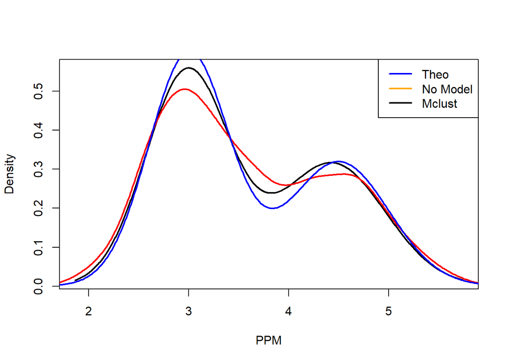

```r
mclust1Dplot(mixModelSample[,1], parameters = EstimatedModel$parameters,what = "density", xlab = "PPM",lwd=2,ylim=c(0,.7))
lines(density(mixModelSample[,1]),col="red",lwd=2)
lines(norMixObj,col="blue",lwd=2)
legend("topright",legend=c("Theo","No Model","Mclust"), lty=1,lwd=2,col=c("blue","orange","black"))
```

Show the classification uncertainty

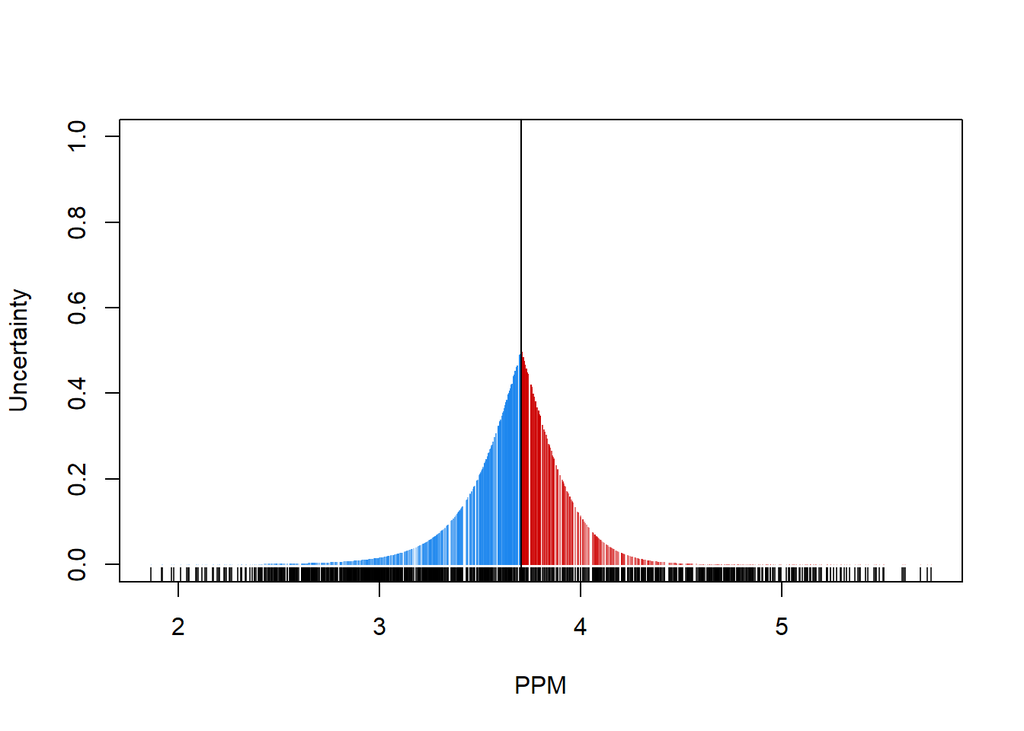

```r
rule<-mixModelSample[which.max(EstimatedModel$uncertainty),1]
mclust1Dplot(mixModelSample[,1], parameters = EstimatedModel$parameters,
             what = "uncertainty",
             z=EstimatedModel$z, xlab = "PPM")
abline(v=rule)
```

where vertical line is at 3.7039228.

This is the classification rule given by `mclust`.  
The classification plot shows that.

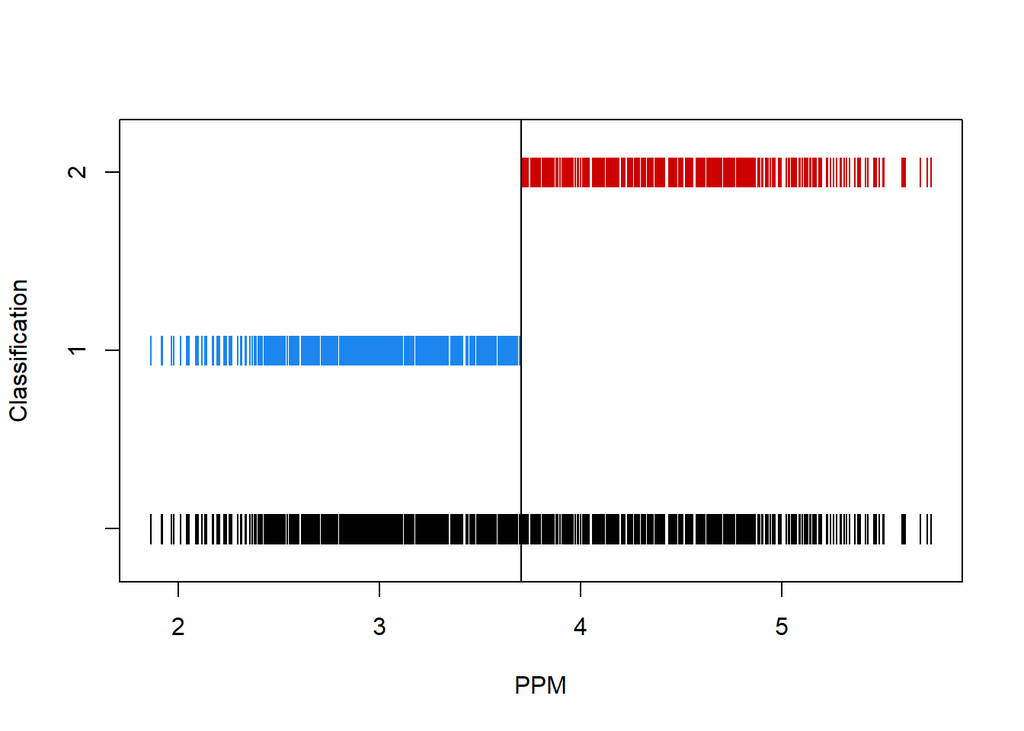

```r
mclust1Dplot(mixModelSample[,1], parameters = EstimatedModel$parameters,
             what = "classification",
             z=EstimatedModel$z, xlab = "PPM")
abline(v=rule)
```

Plot classification errors.

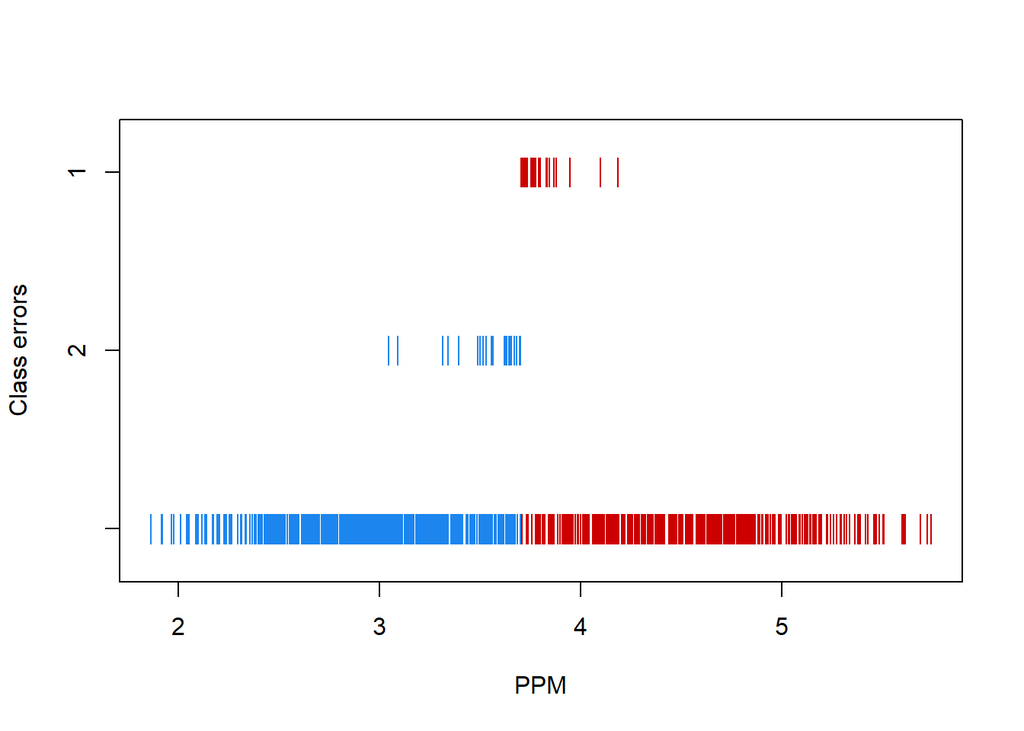

```r
mclust1Dplot(mixModelSample[,1], parameters = EstimatedModel$parameters,
             what = "error",
             truth=mixModelSample[,2],
             z=EstimatedModel$z, xlab = "PPM")
```

Now do the same classification using tree.

*Note that `mclust` did clustering: the method did not use training sample like rpart does.*  
*Of course, in exchange `mclust` knows about the model assumption: normal mixed model.*

Prepare the data for `rpart` and grow the tree.

```r
colnames(mixModelSample)<-c("X","Y")
mixModelSample<-as.data.frame(mixModelSample)
myMixTest<-rpart(Y~X, data=mixModelSample,
              control = rpart.control(cp = 0.00,minbucket=1,minsplit=2),method="class")
printcp(myMixTest)
```

```
##
## Classification tree:
## rpart(formula = Y ~ X, data = mixModelSample, method = "class",
##     control = rpart.control(cp = 0, minbucket = 1, minsplit = 2))
##
## Variables actually used in tree construction:
## [1] X
##
## Root node error: 400/1000 = 0.4
##
## n= 1000
##
##          CP nsplit rel error xerror     xstd
## 1 0.9000000      0    1.0000 1.0000 0.038730
## 2 0.0025000      1    0.1000 0.1125 0.016389
## 3 0.0021429      3    0.0950 0.1225 0.017066
## 4 0.0012500     13    0.0725 0.1300 0.017553
## 5 0.0000000     69    0.0000 0.1675 0.019766
```

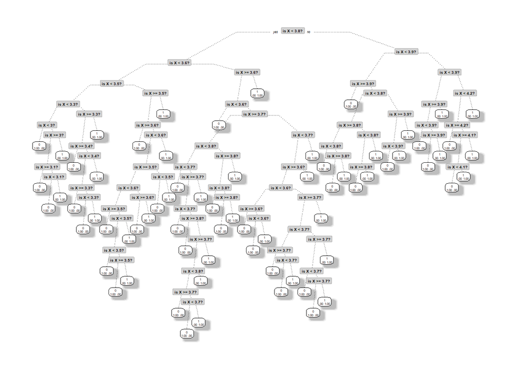

```r
prp(myMixTest,extra=4, # display prob of classes in the node
    branch=.5, # change angle of branch lines
    shadow.col="gray", # shadows under the leaves
    branch.lty=3, # draw branches using dotted lines
    split.cex=1.2, # make the split text larger than the node text
    split.prefix="is ", # put "is " before split text
    split.suffix="?", # put "?" after split text
    split.box.col="lightgray", # lightgray split boxes (default is white)
    split.border.col="darkgray", # darkgray border on split boxes
    split.round=.5)
```

The tree is large, but `xerror` shows that it can be pruned.

```r
(best.CP = myMixTest$cptable[which.min(myMixTest$cptable[,"xerror"]),"CP"])
```

```
## [1] 0.0025
```

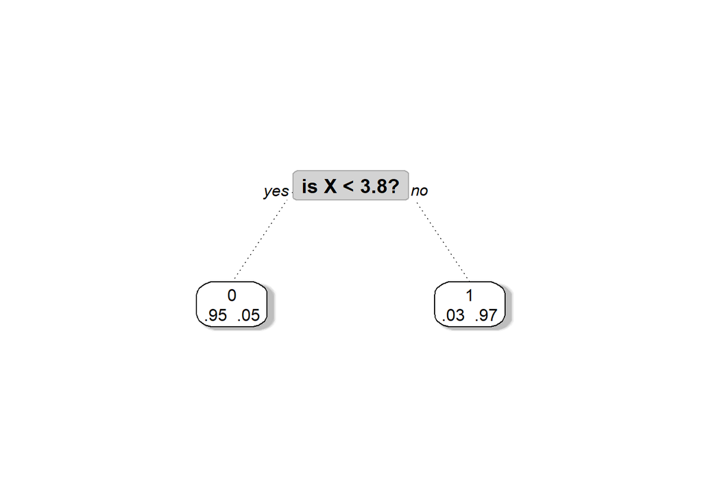

```r
myMixTest.pruned<-prune(myMixTest,best.CP)
prp(myMixTest.pruned,extra=4, # display prob of classes in the node
    branch=.5, # change angle of branch lines
    shadow.col="gray", # shadows under the leaves
    branch.lty=3, # draw branches using dotted lines
    split.cex=1.2, # make the split text larger than the node text
    split.prefix="is ", # put "is " before split text
    split.suffix="?", # put "?" after split text
    split.box.col="lightgray", # lightgray split boxes (default is white)
    split.border.col="darkgray", # darkgray border on split boxes
    split.round=.5)
```

```r
summary(myMixTest.pruned)
```

```
## Call:
## rpart(formula = Y ~ X, data = mixModelSample, method = "class",
##     control = rpart.control(cp = 0, minbucket = 1, minsplit = 2))
##   n= 1000
##
##       CP nsplit rel error xerror       xstd
## 1 0.9000      0       1.0 1.0000 0.03872983
## 2 0.0025      1       0.1 0.1125 0.01638883
##
## Variable importance
##   X
## 100
##
## Node number 1: 1000 observations,    complexity param=0.9
##   predicted class=0  expected loss=0.4  P(node) =1
##     class counts:   600   400
##    probabilities: 0.600 0.400
##   left son=2 (620 obs) right son=3 (380 obs)
##   Primary splits:
##       X < 3.795536 to the left,  improve=403.4295, (0 missing)
##
## Node number 2: 620 observations
##   predicted class=0  expected loss=0.0483871  P(node) =0.62
##     class counts:   590    30
##    probabilities: 0.952 0.048
##
## Node number 3: 380 observations
##   predicted class=1  expected loss=0.02631579  P(node) =0.38
##     class counts:    10   370
##    probabilities: 0.026 0.974
```

Compare classification rule with that of `mclust`.

```r
c(ruleMclust=mixModelSample[which.max(EstimatedModel$uncertainty),1],
  ruleTree=myMixTest.pruned$splits[4])
```

```
## ruleMclust   ruleTree
##   3.703923   3.795536
```

## 2.3 Example: Otto Product Classification

In this example we will use data set, provided by **Otto Group** for **Kaggle** competition [Otto Group Product Classification Challenge](https://www.kaggle.com/c/otto-group-product-classification-challenge).

The goal of the project was categorization about 200,000 unspecified products into 9 classes based on 93 unspecified features.  
For simplicity we reduced in this example the number of products and the number of classes.

### 2.3.1 Structure of the Data

Read the data.

```r
library(fBasics)
```

```r
Data = read.csv(paste(datapath,'DTTrain.csv',sep='/'),header=TRUE)
```

Explore the training data set.

```r
# dataset dimensions
dim(Data)
```

```
## [1] 10233    95
```

```r
# data content
kable(head(Data[,1:5],3))
```

| time | feat_1 | feat_2 | feat_3 | feat_4 |
| --- | --- | --- | --- | --- |
| 45652 | 0 | 0 | 0 | 0 |
| 225646 | 0 | 0 | 0 | 0 |
| 345735 | 0 | 0 | 0 | 0 |

```r
kable(Data[1:3,(ncol(Data)-4):ncol(Data)])
```

| feat_90 | feat_91 | feat_92 | feat_93 | target |
| --- | --- | --- | --- | --- |
| 0 | 0 | 1 | 0 | Class_5 |
| 0 | 1 | 1 | 0 | Class_3 |
| 0 | 0 | 0 | 0 | Class_5 |

Each *column* represents an integer feature.  
Each *row* corresponds to a product.  
The first *column* is the time of information acquisition. The last *column* is the target variable, i.e. the product class. This column is excluded from the test data.

```r
classColName = tail(colnames(Data),1)
Data[1:5,classColName]
```

```
## [1] "Class_5" "Class_3" "Class_5" "Class_5" "Class_5"
```

The class variable is a character string in the **95**-th column called **target**.

```r
set.seed(5)
xTrain = Data[sample(nrow(Data)),-1] # remove time stamp
dim(xTrain)
```

```
## [1] 10233    94
```

```r
xTrain[1:2,(ncol(Data)-4):(ncol(Data)-1)]
```

```
##      feat_91 feat_92 feat_93  target
## 2255       0       0       0 Class_5
## 6859       0       0       0 Class_2
```

### 2.3.2 Creating and Plotting Small Classification Tree

Create formula for the tree.

```r
(formula = formula(paste(classColName,'.',sep='~')))
```

```
## target ~ .
```

```r
set.seed(9)
smallTree <- rpart(formula,
                   data=xTrain,
                   control = rpart.control(minbucket=250,
                                           cp=.0001))
```

Analyze `printcp()`.

```r
printcp(smallTree)
```

```
##
## Classification tree:
## rpart(formula = formula, data = xTrain, control = rpart.control(minbucket = 250,
##     cp = 1e-04))
##
## Variables actually used in tree construction:
##  [1] feat_14 feat_15 feat_32 feat_34 feat_36 feat_39 feat_40 feat_41 feat_62
## [10] feat_67 feat_8  feat_86 feat_88 feat_9
##
## Root node error: 6286/10233 = 0.61429
##
## n= 10233
##
##          CP nsplit rel error  xerror      xstd
## 1 0.1880369      0   1.00000 1.00000 0.0078333
## 2 0.1784919      1   0.81196 0.83567 0.0080435
## 3 0.0738148      2   0.63347 0.63347 0.0078460
## 4 0.0561565      3   0.55966 0.55966 0.0076435
## 5 0.0176053      4   0.50350 0.50652 0.0074503
## 6 0.0058861      7   0.45068 0.45132 0.0072036
## 7 0.0046134      9   0.43891 0.44130 0.0071535
## 8 0.0017499     12   0.42507 0.43191 0.0071049
## 9 0.0001000     14   0.42157 0.43430 0.0071174
```

The table in the output shows the summary of the fitted tree.  
Rows correspond to different sizes of the tree.  
The table has the following columns:

- `CP` shows complexity parameter controlling the tree size
- `nsplit` - number of splitting nodes in the tree
- `rel error` - the error of the training set relative to the error with no splits
- `xerror` - the relative error of the test set calculated with k-fold cross validation (by default k=10)
- `xstd` - standard deviation of `xerror`

Plot cross validation x-error versus tree size (and complexity parameter).

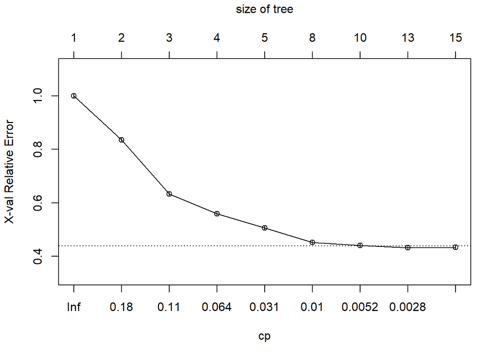

```r
plotcp(smallTree)
```

The horizontal dotted line shows the level of 1 standard error `xstd` above the minimum of `xerror`.  
To prune the tree select the level of `cp` corresponding to the first point from the left below the standard error line.

Another way of selecting the parameter `cp` is:

```r
(best.CP =
   smallTree$cptable[which.min(smallTree$cptable[,"xerror"]),"CP"])
```

```
## [1] 0.00174992
```

Both `plotcp()` and `best.CP` show that we can prune `smallTree` reducing the number of splits in it.

Visualize the tree using `prp()`.

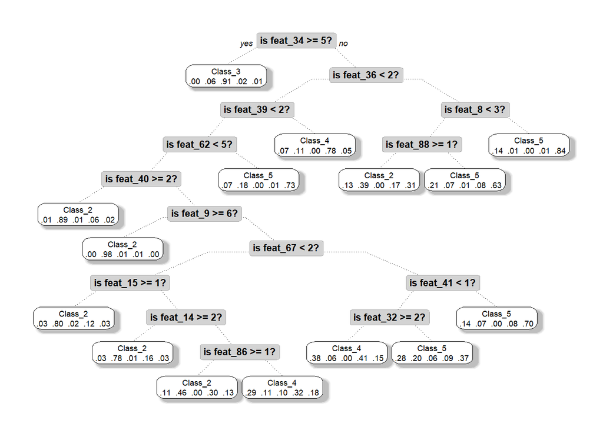

```r
prp(smallTree,extra=4, # display prob of classes in the node
    branch=.5, # change angle of branch lines
    shadow.col="gray", # shadows under the leaves
    branch.lty=3, # draw branches using dotted lines
    split.cex=1.2, # make the split text larger than the node text
    split.prefix="is ", # put "is " before split text
    split.suffix="?", # put "?" after split text
    split.box.col="lightgray", # lightgray split boxes (default is white)
    split.border.col="darkgray", # darkgray border on split boxes
    split.round=.5)
```

Function `prune()` returns new `rpart` object that is trimmed to the value of optimal CP.

```r
prunedTree <- prune(smallTree, cp = best.CP)
printcp(prunedTree)
```

```
##
## Classification tree:
## rpart(formula = formula, data = xTrain, control = rpart.control(minbucket = 250,
##     cp = 1e-04))
##
## Variables actually used in tree construction:
##  [1] feat_14 feat_15 feat_32 feat_34 feat_36 feat_39 feat_40 feat_41 feat_62
## [10] feat_67 feat_86 feat_9
##
## Root node error: 6286/10233 = 0.61429
##
## n= 10233
##
##          CP nsplit rel error  xerror      xstd
## 1 0.1880369      0   1.00000 1.00000 0.0078333
## 2 0.1784919      1   0.81196 0.83567 0.0080435
## 3 0.0738148      2   0.63347 0.63347 0.0078460
## 4 0.0561565      3   0.55966 0.55966 0.0076435
## 5 0.0176053      4   0.50350 0.50652 0.0074503
## 6 0.0058861      7   0.45068 0.45132 0.0072036
## 7 0.0046134      9   0.43891 0.44130 0.0071535
## 8 0.0017499     12   0.42507 0.43191 0.0071049
```

Plot the pruned tree.

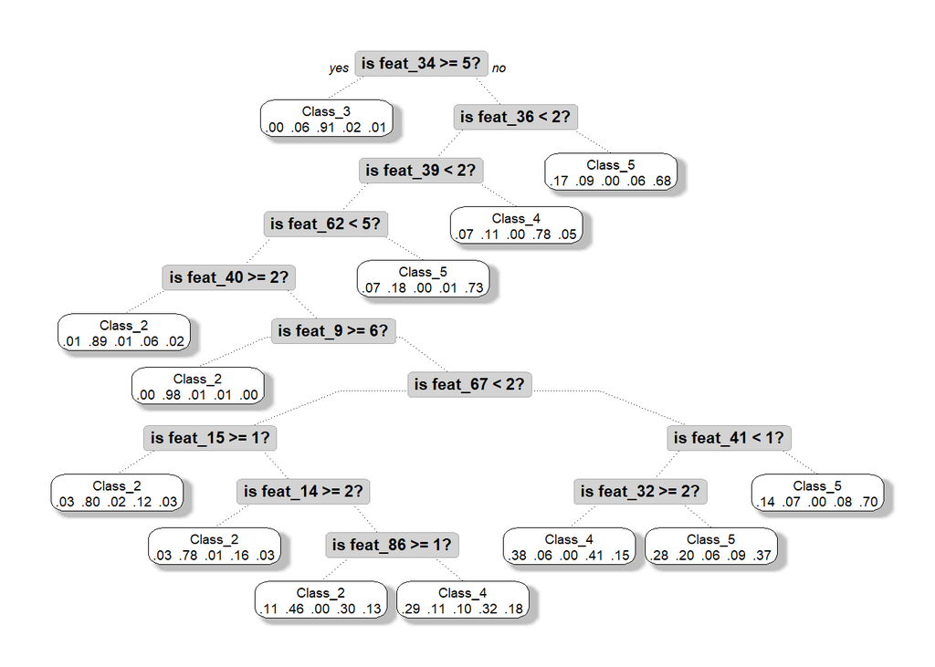

```r
prp(prunedTree,extra=4, # display prob of classes in the node
    branch=.5, # change angle of branch lines
    shadow.col="gray", # shadows under the leaves
    branch.lty=3, # draw branches using dotted lines
    split.cex=1.2, # make the split text larger than the node text
    split.prefix="is ", # put "is " before split text
    split.suffix="?", # put "?" after split text
    split.box.col="lightgray", # lightgray split boxes (default is white)
    split.border.col="darkgray", # darkgray border on split boxes
    split.round=.5)
```

Now predict probabilities that an observation belongs to each class for the first 2 rows of `xTtrain`.  
Select the first 2 rows of `xTrain` and predict them using `smallTree`.

```r
test = xTrain[1:2,-ncol(xTrain)]
(distr = predict(smallTree,test))
```

```
##        Class_1     Class_2     Class_3    Class_4   Class_5
## 2255 0.1374408 0.005924171 0.001184834 0.01184834 0.8436019
## 6859 0.1098131 0.457943925 0.000000000 0.30373832 0.1285047
```

**Check if the observations were classified correctly**.

```r
class = apply(distr,1,which.max)
actual<-xTrain[1:2,ncol(xTrain)]
cbind(class,actual)
```

```
##      class actual
## 2255 "5"   "Class_5"
## 6859 "2"   "Class_2"
```

```r
actual<-factor(actual,levels=paste0("Class_",1:5))
```

Calculate log loss penalty function

```r
library(dummies)
```

```r
(rf_target_IndMat<-
   as.matrix(dummy.data.frame(data=as.data.frame(actual),
                                     sep="_", verbose=F,
                                     dummy.classes="ALL",drop=F)))
```

```
##   actual_Class_1 actual_Class_2 actual_Class_3 actual_Class_4 actual_Class_5
## 1              0              0              0              0              1
## 2              0              1              0              0              0
```

```r
(rfLogLoss = MultiLogLoss(rf_target_IndMat,distr))
```

```
## [1] 0.4755416
```

This example shows how “tough” is the logloss measure: even though both classes are classified correctly if decision is made by maximizing probability in the vector of predictions, the measure punishes for lack of confidence.

See the contribution of each observation

```r
MultiLogLoss(rf_target_IndMat[1,],distr[1,])
```

```
## [1] 0.1700746
```

```r
MultiLogLoss(rf_target_IndMat[2,],distr[2,])
```

```
## [1] 0.7810085
```

# 3 Trees vs. Linear Models

Compare work of tree model and linear logistic regression model as binary classification methods. Logistic regression partitions feature space by one hyper plane.  
Obtained semispaces define the two classes.  
Classification tree algorithm recursively partitions feature space by a hyper planes orthogonal to one of the axes. So, the resulting critical domain can be much more complex than semispace.

Consider the following two examples.

## 3.1 Example. Galton’s data

Galton’s data on the heights of parents and their children can be found in package **HistData**.  
This data set lists the individual observations for 934 children in 205 families on which Galton (1886) based his cross-tabulation.

```r
library(HistData)
data(GaltonFamilies)
```

Families are largely listed in descending order of fathers and mothers height.

Reshuffle them to ensure correct cross validation procedure.

```r
set.seed(0)
GaltonFamilies = GaltonFamilies[sample(nrow(GaltonFamilies)),]
str(GaltonFamilies)
```

```
## 'data.frame':    934 obs. of  8 variables:
##  $ family         : Factor w/ 205 levels "001","002","003",..: 92 182 148 35 204 115 107 72 68 49 ...
##  $ father         : num  70 66.5 68.5 71 62 69 69 70 70.5 71.5 ...
##  $ mother         : num  61 62.5 63.5 69 66 63.5 66 65 65 64.5 ...
##  $ midparentHeight: num  67.9 67 68.5 72.8 66.6 ...
##  $ children       : int  2 7 1 5 3 7 9 7 5 7 ...
##  $ childNum       : int  2 5 1 2 1 3 3 7 2 5 ...
##  $ gender         : Factor w/ 2 levels "female","male": 2 1 2 2 2 2 2 1 1 1 ...
##  $ childHeight    : num  67 62.5 68.2 74 64 66 69 62 65 64.5 ...
```

Note that mid-parent height is calculated as  
`midparentHeight = (father + 1.08*mother)/2`  
The goal is to identify each child gender by her or his height and mid-parent height.  
Look at the data scatterplot.

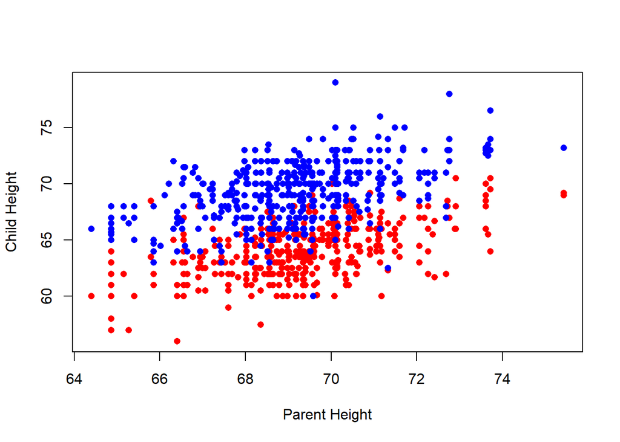

```r
Gender = as.character(GaltonFamilies$gender)=="female"
plot(GaltonFamilies$midparentHeight[Gender],GaltonFamilies$childHeight[Gender],type="p",pch=16,col="red",
     ylim=c(min(GaltonFamilies$childHeight),max(GaltonFamilies$childHeight)),ylab="Child Height",xlab="Parent Height")
points(GaltonFamilies$midparentHeight[!Gender],GaltonFamilies$childHeight[!Gender],type="p",pch=16,col="blue")
```

Apply Logistic Regression to the data.

```r
modelFormula = formula('gender ~ midparentHeight + childHeight')
logrFit <- glm(modelFormula, family=binomial("logit"),data=GaltonFamilies)
beta = as.numeric(logrFit$coefficients)
beta
```

```
## [1] -18.7653673  -0.7668881   1.0802791
```

The equation of the line, separating target classes is
$$f(x)=-(\beta _{0}+\beta _{1}x)/\beta _{2}$$

Draw it on the plot above.

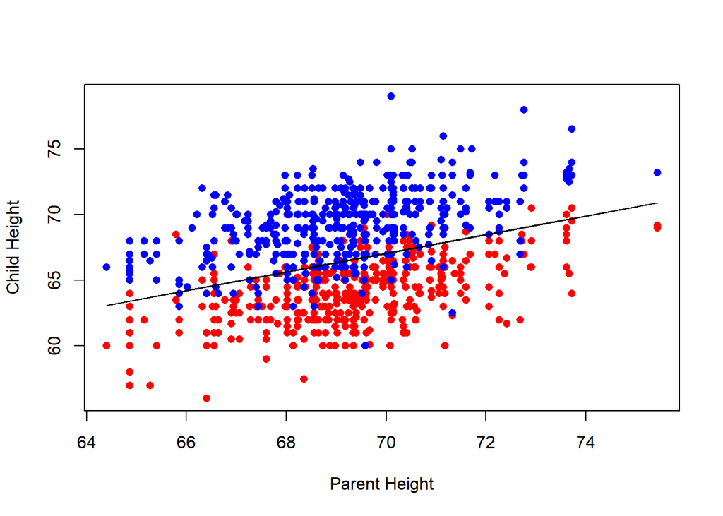

```r
f.x <-  -(beta[1]+beta[2]*GaltonFamilies$midparentHeight)/beta[3]
plot(GaltonFamilies$midparentHeight[Gender],GaltonFamilies$childHeight[Gender],type="p",pch=16,col="red",
     ylim=c(min(GaltonFamilies$childHeight),max(GaltonFamilies$childHeight)),ylab="Child Height",xlab="Parent Height")
points(GaltonFamilies$midparentHeight[!Gender],GaltonFamilies$childHeight[!Gender],type="p",pch=16,col="blue")
lines(GaltonFamilies$midparentHeight,f.x,col="black")
```

We see that in spite of high noise level straight line successfully separates male and female items.

Let us check the predictive quality of the method with 10-fold cross validation implemented in the **caret** package.

```r
library(caret)
ctrl <- trainControl(method = "cv", number = 10)
logrTrain <- train(modelFormula,data=GaltonFamilies,
                   method = 'glm', trControl = ctrl)
summary(logrTrain)
```

```
##
## Call:
## NULL
##
## Deviance Residuals:
##     Min       1Q   Median       3Q      Max
## -3.0947  -0.3578   0.0346   0.2975   3.8234
##
## Coefficients:
##                  Estimate Std. Error z value Pr(>|z|)
## (Intercept)     -18.76537    4.51948  -4.152 3.29e-05 ***
## midparentHeight  -0.76689    0.07866  -9.750  < 2e-16 ***
## childHeight       1.08028    0.07065  15.290  < 2e-16 ***
## ---
## Signif. codes:  0 '***' 0.001 '**' 0.01 '*' 0.05 '.' 0.1 ' ' 1
##
## (Dispersion parameter for binomial family taken to be 1)
##
##     Null deviance: 1293.96  on 933  degrees of freedom
## Residual deviance:  510.38  on 931  degrees of freedom
## AIC: 516.38
##
## Number of Fisher Scoring iterations: 6
```

```r
logrTrain$results
```

```
##   parameter  Accuracy     Kappa AccuracySD  KappaSD
## 1      none 0.8822666 0.7645139 0.01996013 0.040087
```

Now classify the data using trees from **rpart** package.

```r
set.seed(0)
treeFit <- rpart(modelFormula, data=GaltonFamilies)
printcp(treeFit)
```

```
##
## Classification tree:
## rpart(formula = modelFormula, data = GaltonFamilies)
##
## Variables actually used in tree construction:
## [1] childHeight     midparentHeight
##
## Root node error: 453/934 = 0.48501
##
## n= 934
##
##         CP nsplit rel error  xerror     xstd
## 1 0.688742      0   1.00000 1.00000 0.033717
## 2 0.023179      1   0.31126 0.31567 0.024293
## 3 0.015453      3   0.26490 0.29139 0.023502
## 4 0.010000      5   0.23400 0.25828 0.022332
```

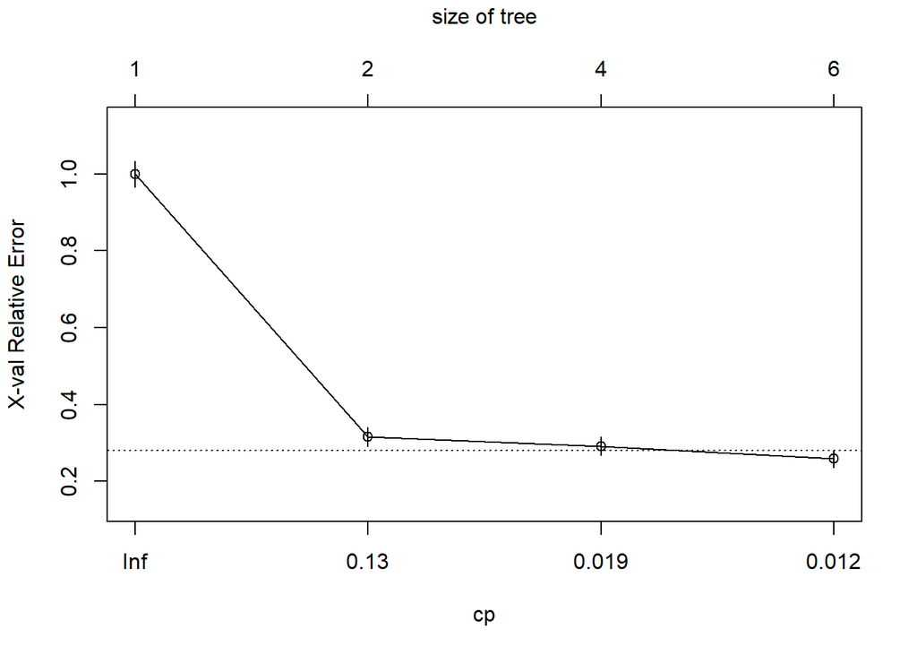

```r
plotcp(treeFit)
```

```r
summary(treeFit)
```

```
## Call:
## rpart(formula = modelFormula, data = GaltonFamilies)
##   n= 934
##
##           CP nsplit rel error    xerror       xstd
## 1 0.68874172      0 1.0000000 1.0000000 0.03371708
## 2 0.02317881      1 0.3112583 0.3156733 0.02429319
## 3 0.01545254      3 0.2649007 0.2913907 0.02350187
## 4 0.01000000      5 0.2339956 0.2582781 0.02233224
##
## Variable importance
##     childHeight midparentHeight
##              77              23
##
## Node number 1: 934 observations,    complexity param=0.6887417
##   predicted class=male    expected loss=0.4850107  P(node) =1
##     class counts:   453   481
##    probabilities: 0.485 0.515
##   left son=2 (476 obs) right son=3 (458 obs)
##   Primary splits:
##       childHeight     < 66.85  to the left,  improve=228.033300, (0 missing)
##       midparentHeight < 68.55  to the right, improve=  1.334296, (0 missing)
##   Surrogate splits:
##       midparentHeight < 69.404 to the left,  agree=0.596, adj=0.177, (0 split)
##
## Node number 2: 476 observations,    complexity param=0.02317881
##   predicted class=female  expected loss=0.1722689  P(node) =0.509636
##     class counts:   394    82
##    probabilities: 0.828 0.172
##   left son=4 (387 obs) right son=5 (89 obs)
##   Primary splits:
##       childHeight     < 65.6   to the left,  improve=16.819230, (0 missing)
##       midparentHeight < 66.54  to the right, improve= 6.857383, (0 missing)
##
## Node number 3: 458 observations,    complexity param=0.01545254
##   predicted class=male    expected loss=0.128821  P(node) =0.490364
##     class counts:    59   399
##    probabilities: 0.129 0.871
##   left son=6 (213 obs) right son=7 (245 obs)
##   Primary splits:
```

[output cut: 39 more lines]

```
##
## Node number 11: 51 observations
##   predicted class=male    expected loss=0.2941176  P(node) =0.05460385
##     class counts:    15    36
##    probabilities: 0.294 0.706
##
## Node number 12: 50 observations
##   predicted class=female  expected loss=0.36  P(node) =0.05353319
##     class counts:    32    18
##    probabilities: 0.640 0.360
##
## Node number 13: 163 observations
##   predicted class=male    expected loss=0.1288344  P(node) =0.1745182
##     class counts:    21   142
##    probabilities: 0.129 0.871
```

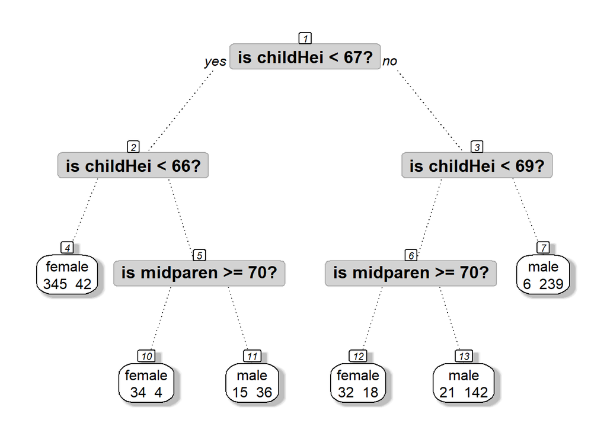

```r
prp(treeFit,extra=1, # display the number of observations that fall in the node
    branch=.5, # change angle of branch lines
    shadow.col="gray", # shadows under the leaves
    branch.lty=3, # draw branches using dotted lines
    split.cex=1.2, # make the split text larger than the node text
    split.prefix="is ", # put "is " before split text
    split.suffix="?", # put "?" after split text
    split.box.col="lightgray", # lightgray split boxes (default is white)
    split.border.col="darkgray", # darkgray border on split boxes
    split.round=.5,
    nn=TRUE) # display the node numbers, default is FALSE
```

Output `printcp` shows that only the root node split significantly reduces impurity.

```r
sp <- ggplot(GaltonFamilies, aes(x=midparentHeight, y=childHeight, color=Gender)) + geom_point()+ scale_color_hue(l=65, c=100)+ scale_color_manual(values=c("red", "blue"))
```

[output not shown]

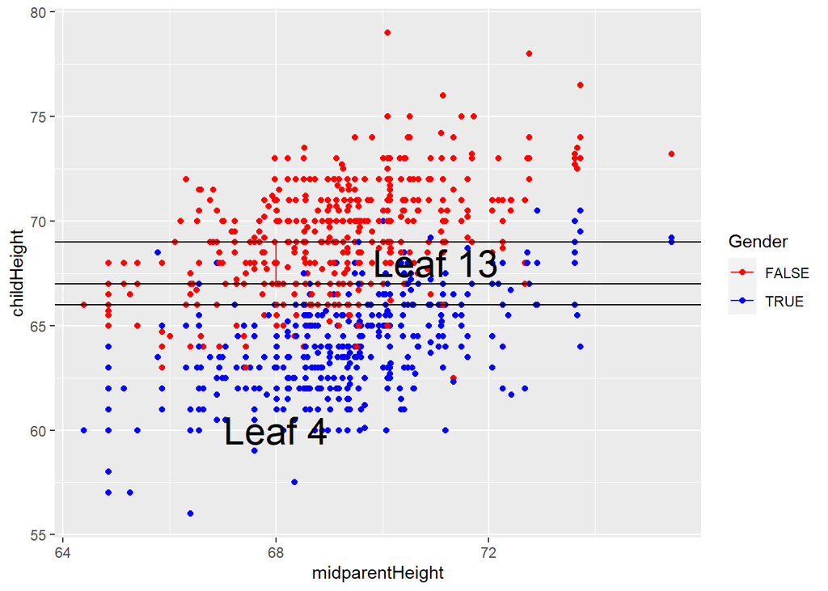

```r
sp1 <- sp   + geom_hline(yintercept=67)
sp1 <- sp1   + geom_hline(yintercept=66)
sp1 <- sp1   + geom_hline(yintercept=69)
sp1 <- sp1 +  geom_segment(aes(x = 68, y = 67,xend = 68,yend = 69))
sp1 <- sp1 + annotate(geom="text", x=68, y=60, label="Leaf 4",
                      color="black",size=8)
sp1 <- sp1 + annotate(geom="text", x=71, y=68, label="Leaf 13",
                      color="black",size=8)
sp1
```

Finally test tree prediction quality and compare it with the one displayed by logistic regression.

```r
treeTrain <- train(modelFormula, method="rpart",data=GaltonFamilies,
                   trControl = ctrl)
treeTrain$results
```

```
##           cp  Accuracy     Kappa AccuracySD    KappaSD
## 1 0.01545254 0.8660806 0.7319639 0.03243316 0.06488076
## 2 0.02317881 0.8511860 0.7021675 0.02692814 0.05373901
## 3 0.68874172 0.6720280 0.3292082 0.16566641 0.34733483
```

```r
logrTrain$results
```

```
##   parameter  Accuracy     Kappa AccuracySD  KappaSD
## 1      none 0.8822666 0.7645139 0.01996013 0.040087
```

**Accuracy** as well as **kappa** show that linear classifier outperforms trees on these data. The main reason is that trapezoid, generated by logistic regression is a good approximation for the shapes of both target classes.

## 3.2 Example. Rectangular class domain

Simulate the data with rectangular shapes of classes.  
Each observation is three-dimensional vector with two numeric features and one categorical (type) with possible values ‘Positive’ or ‘Negative’.  
The goal is to identify type on the basis of first two features.

```r
N = 1000
xPos = 0.2
yMinPos = 0.2
yMaxPos = 0.7
newData = data.frame(x=runif(N),y=runif(N))
newData$type = with(newData,ifelse(x>xPos & y>yMinPos & y<yMaxPos,
                        'Positive','Negative'))
```

Add some noise at the beginning of the data and reshuffle.

```r
n = N/10
newData$type[1:n] = c('Positive','Negative')[1+rbinom(n, 1, 0.5)]
newData = newData[sample(nrow(newData)),]
```

Plot the data

[output not shown]

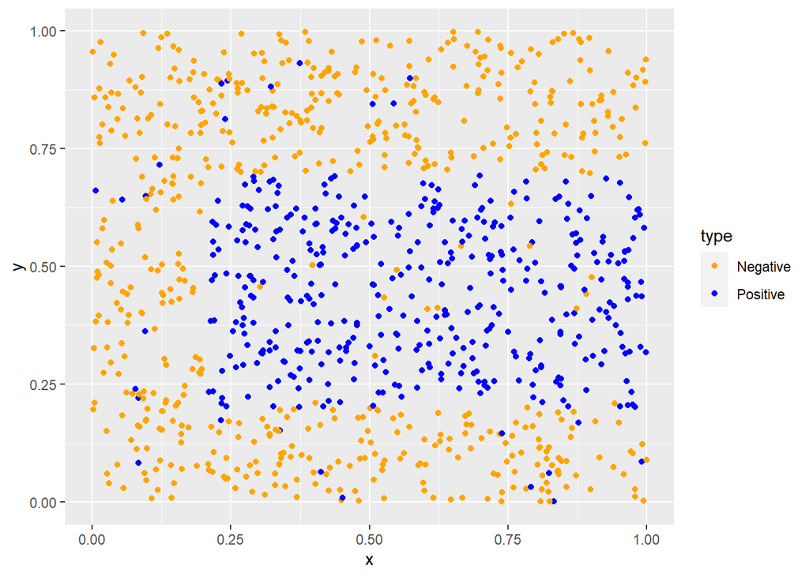

```r
ggplot(newData, aes(x=x, y=y, color=type)) + geom_point()+ scale_color_hue(l=65, c=100)+ scale_color_manual(values=c("orange", "blue"))
```

Fit logistic regression and tree model with `caret` and compare their predictive quality.

(Skipped Code)

```r
newModelFormula = formula('type~.')
logrTrain <- train(newModelFormula,data=newData,method = 'glm', trControl = ctrl)
treeTrain <- train(newModelFormula, method="rpart",data=newData,trControl = ctrl)
```

```r
treeTrain$results
```

```
##          cp  Accuracy     Kappa AccuracySD    KappaSD
## 1 0.0000000 0.9539473 0.9045408 0.01277823 0.02673030
## 2 0.1961259 0.9051136 0.8086704 0.04976480 0.09714545
## 3 0.3510896 0.7209761 0.3543616 0.14056614 0.37409640
```

```r
logrTrain$results
```

```
##   parameter  Accuracy     Kappa AccuracySD  KappaSD
## 1      none 0.6048735 0.1445363 0.04965237 0.113939
```

Rectangular shape of the Positive class domain surrounded by the opposite class points, of course, gives significant advantage to tree classification over linear method.